# Baseball Analytics

## Syllabus

- Basic Graphs
- Run Expectancy
- The Relation between Runs and Wins
- Career Trajectories

## Basic Graphs

Need package: "graphics"

Need datafiles: "hofbatting.csv"

- Generate traditional graphs for factor variable and numeric variable.
- Scatter plots, pie pots, histogram, boxplots, etc.
- Identify particular points from a plot.
- Title, legend, axis lable, etc., for a graph.

## Graphs for Factor Variables

- Create a new factor variable "Era" from numeric variable "MidCareer".
- **Frequency Table**

```
##
## 19th Century  Lively Ball    Dead Ball  Integration    Expansion
##           17           19           46           24           21
##  Free Agency    Long Ball
##           18            2
```

- **Bar Graph & Pie Graph**

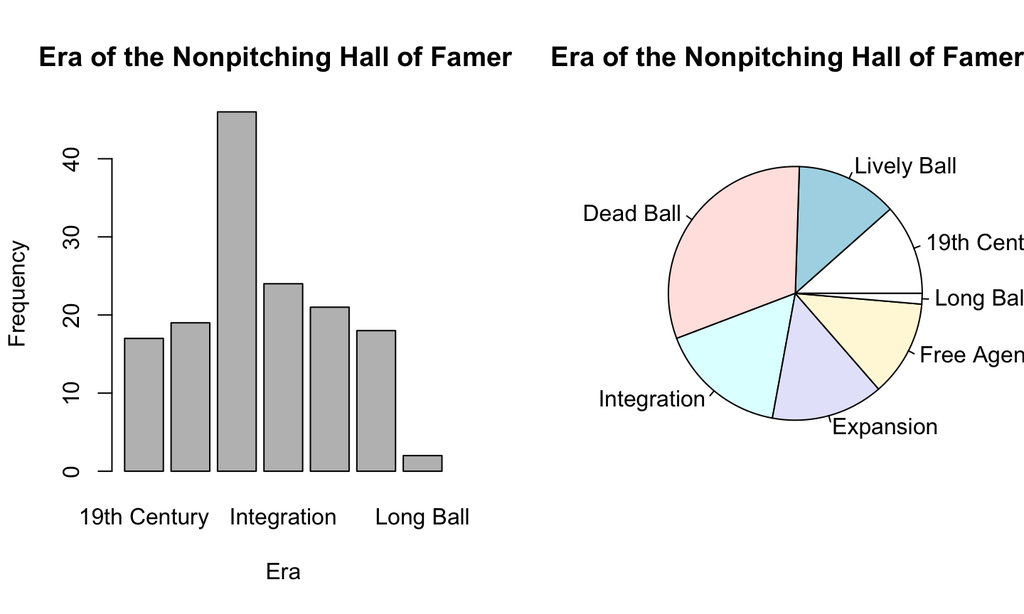

- **Dotplot**

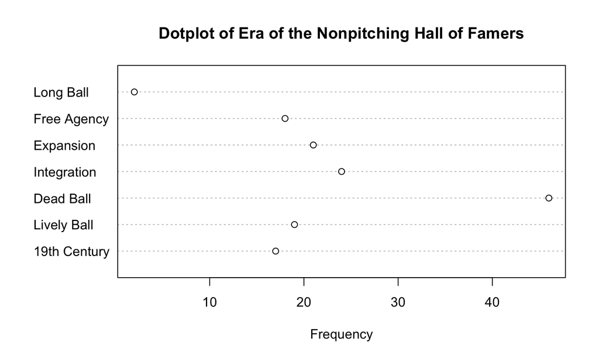

## Graphs for Numeric Variables

- **Scatterplot & Stripchart**

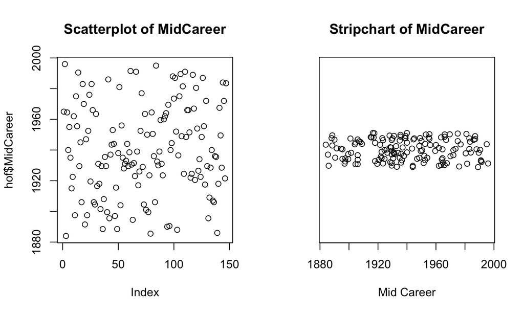

- **Histogram & Density Plot**

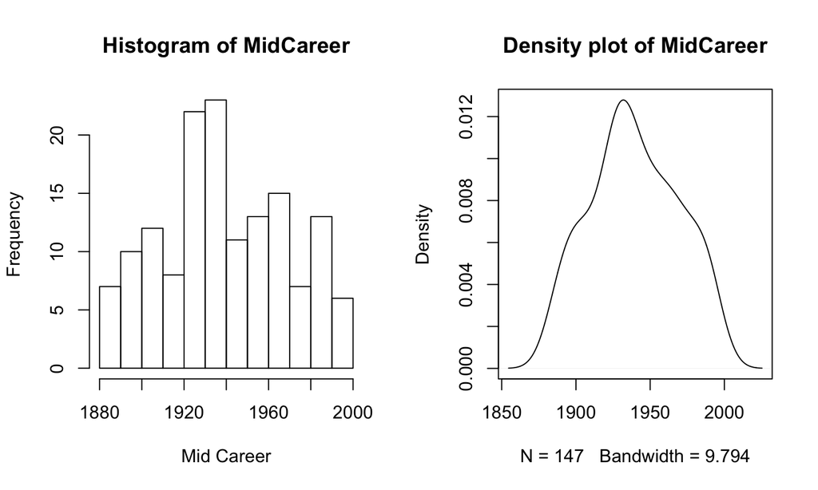

## Graphs for Two Variables

- **Scatterplot & Smoothing Curve**
- How to identify specific points on a graph?

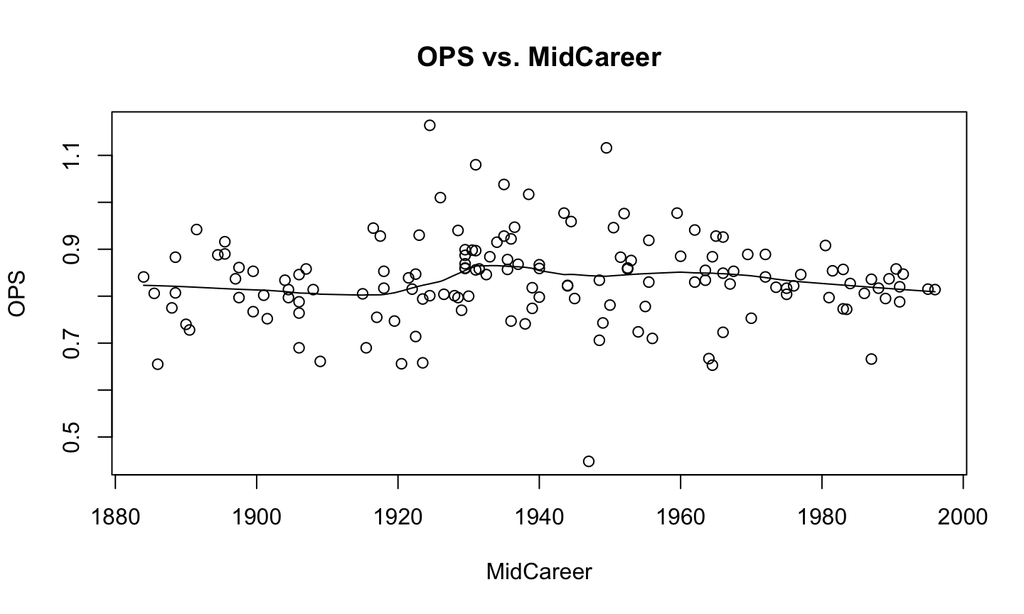

- **Parallel Stripcharts**

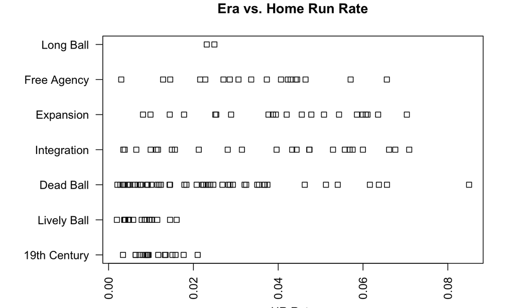

- **Side-by-Side Boxplot**

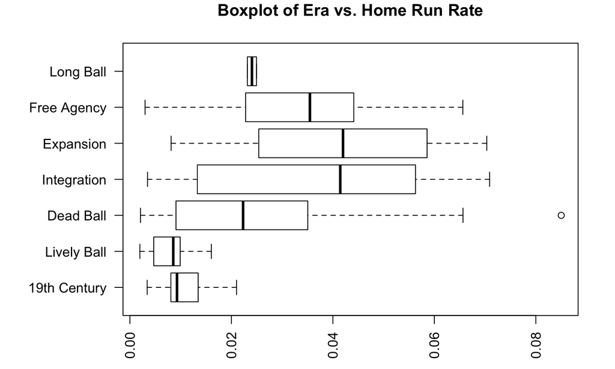

How to save the graphs?

## Exercises

## The Relation between Runs and Wins

Need packages: "stats"

Need datafile: "teams.csv"

- Introduction to linear regression.
- The Pythagorean formula for winning percentage.
- Prediction by Pythagorean formula and residuals.

The *teams.csv* file from Lahman's database contains seasonal stats for major league teams.

Select the subset and calculate the new variables of interest.

```
##      teamID yearID lgID   G  W  L   R  RA  RD      Wpct
## 2710    PHI   2012   NL 162 81 81 684 680   4 0.5000000
## 2711    PIT   2012   NL 162 79 83 651 674 -23 0.4876543
## 2712    SDN   2012   NL 162 76 86 651 710 -59 0.4691358
## 2713    SFN   2012   NL 162 94 68 718 649  69 0.5802469
## 2714    SLN   2012   NL 162 88 74 765 648 117 0.5432099
## 2715    WAS   2012   NL 162 98 64 731 594 137 0.6049383
```

## Linear Regression

A *Simple Linear Model*(SLM) has the following formula: \[ Response = a + b \times Predictor + \epsilon \] where *a* and *b* are unknown constants and \(\epsilon\) is the error term which captures all other factors influencing the dependent variable (Response).

- Linear relationship
- Normality
- No multicollinearity
- No auto-correlation
- Homoscedasticity

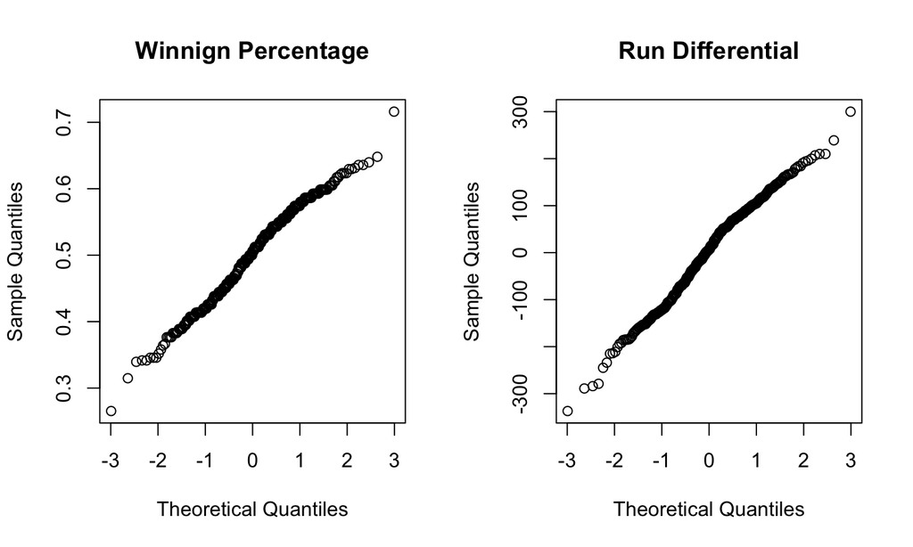

Fit the regression line by "lm" function in "stats" package.

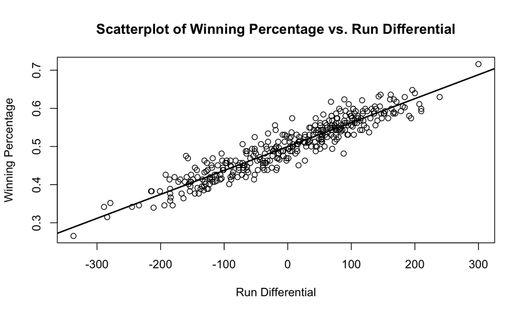

- **Residual Plot**

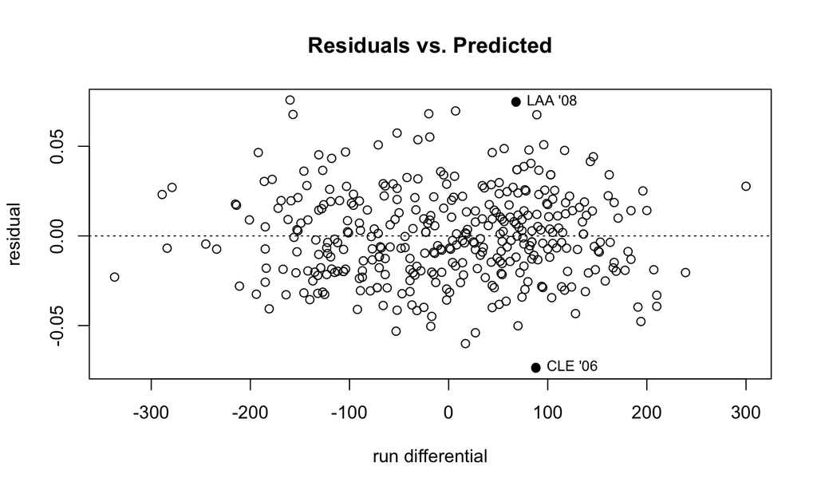

- Diagnostic Plot

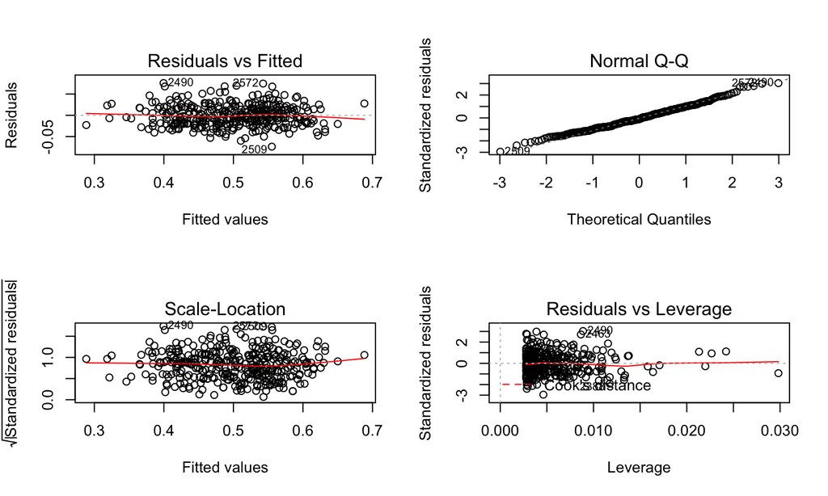

## Pythagorean Formula

Bill James empirically derived the non-linear formula to estimate winning percentage, called the Pythagorean expectation \[ Wpct = \frac{R^2}{R^2+RA^2} \]

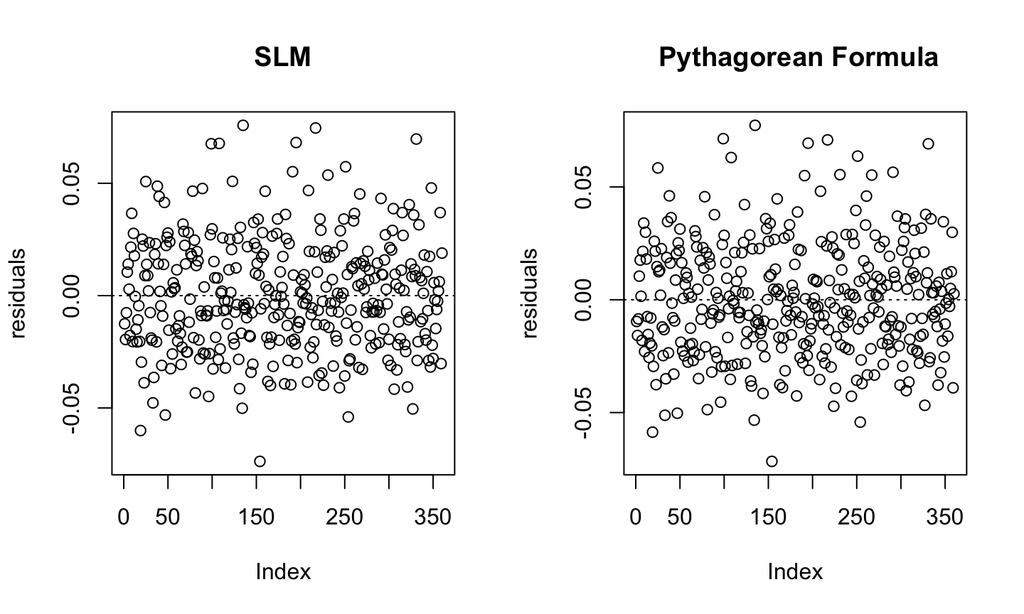

## Run Expectancy

Need package: "plyr"

Need datafile: "all2011.csv", "fields.csv", "roster2011.csv"

- Find the Runs Expectancy Matrixs
- **The Runs Expectancy Matrix**

Each base can be occupied by a runner or empty.

The number of outs can be 0, 1, or 2.

For each combination, one is interested in computing the average number of runs scored in the remainder of the inning.

Arrange the average runs as a table classified by runners and outs, this display is called the **Runs Expectancy Matrix**.

```
##     0 outs 1 out 2 outs 0 outs 1 out 2 outs
## 000   0.47  0.25   0.10   0.51  0.27   0.10
## 001   1.45  0.94   0.32   1.40  0.94   0.36
## 010   1.06  0.65   0.31   1.14  0.68   0.32
## 011   1.93  1.34   0.54   1.96  1.36   0.63
## 100   0.84  0.50   0.22   0.90  0.54   0.23
## 101   1.75  1.15   0.49   1.84  1.18   0.52
## 110   1.41  0.87   0.42   1.51  0.94   0.45
## 111   2.17  1.47   0.76   2.33  1.51   0.78
```

## Case Study: Albert Pujols

Let's focus on the plate appearance for the great hitter *Albert Pujols* for the 2011 season. We consider only the batting plays where Albert was the hitter, and show the original state, new state, and run value variables for the first two plate appearances in this season.

```
##      STATE NEW.STATE RUNS.VALUE
## 6556 100 1     000 3 -0.4960492
## 6574 001 2     001 3 -0.3173913
```

## Albert Pujols

- Unfinished

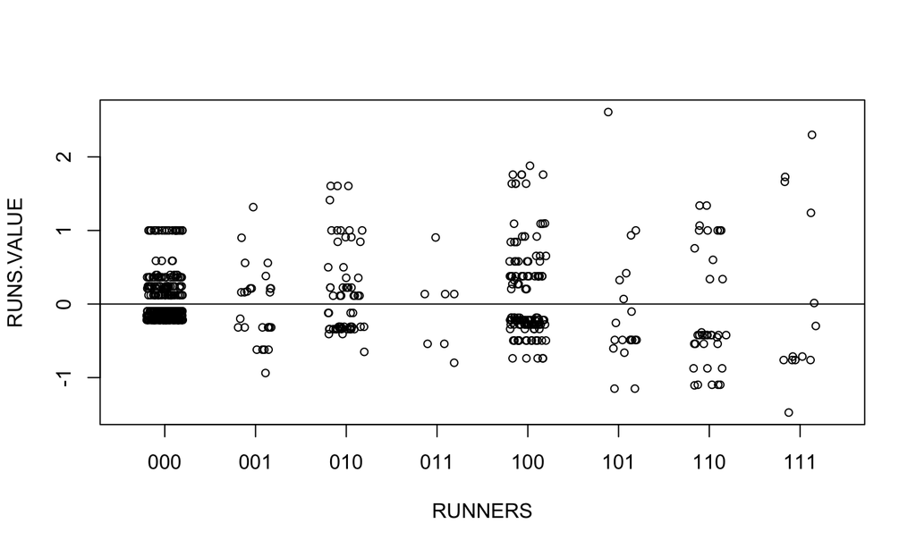

## Albert Pujols

- Unfinished

```
##   Group.1  PA       RUNS
## 1     000 354 10.7568515
## 2     001  27 -0.9417766
## 3     010  60  9.6399002
## 4     011   7 -0.5680439
## 5     100 135 14.2174870
## 6     101  19 -1.9853612
## 7     110  36 -4.5593651
## 8     111  13  0.6971003
```

## Albert Pujols

- Unfinished

## Opportunity for All Hitters

-Unfinished

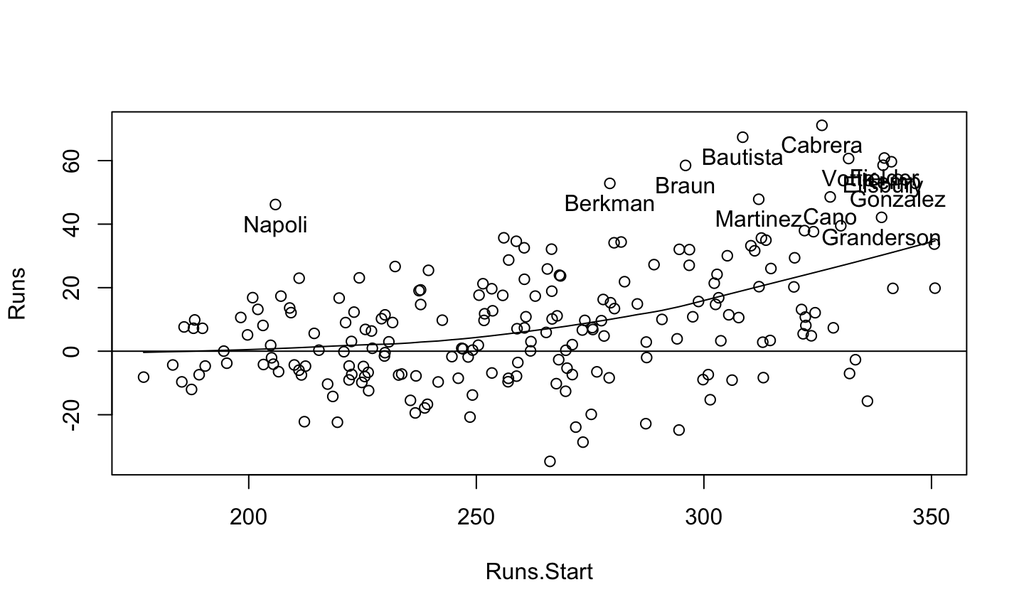

## Career Trajectories [30 minutes]

Need package: "car", "plyr"

Need datafiles: "Batting.csv", "Master.csv", "Fielding.csv"

- Get the general information for players from a dataset.
- Fit and plot trajectories.
- Compare different players by computing similarity scores.
- Find the peak age for players.

## Mickey Mantel's Batting Trajectory

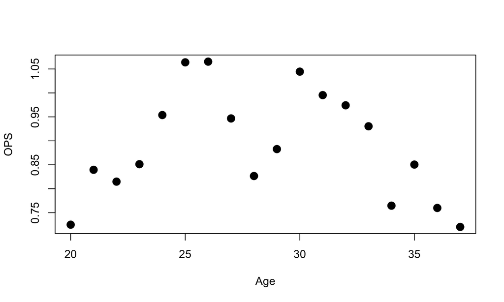

## Smooth Curve

A convenient choice of smooth curve is a quadratic function of the form ( why subtract 30? ): \[ A + B (Age-30) + C(Age-30)^2 \]

Answer the following questions:

- What's the pratical meaning of the constant *A*?
- What's the pratical meaning of the coefficient *C*?
- When does the function reach its largest value?
- What is the maximum value of the curve?

## Fit the Smooth Curve

```
##     (Intercept)     I(Age - 30) I((Age - 30)^2)
##     0.972202241    -0.013248087    -0.003520738
```

```
## I(Age - 30) (Intercept)
##   28.118564    0.984665
```

## Fit the Smooth Curve

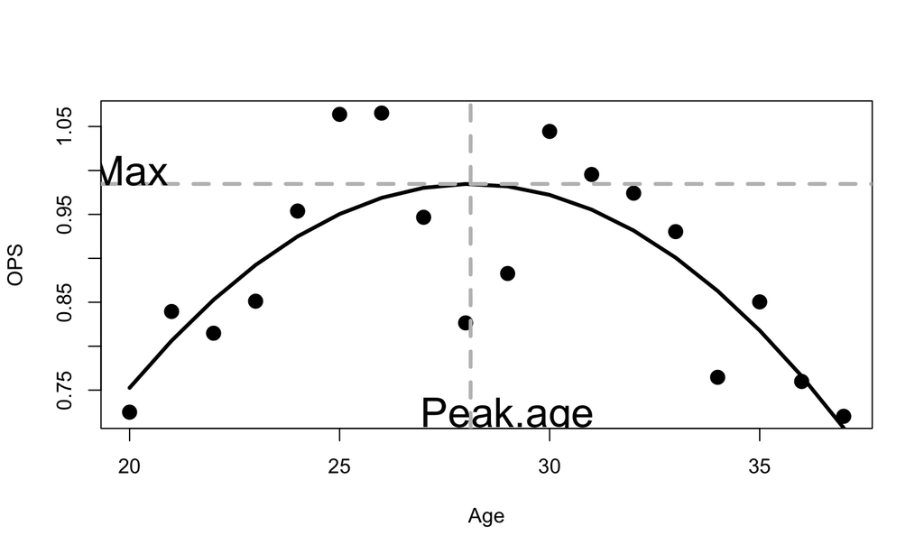

## Fit the Smooth Curve

```r
summary(F2$fit)
```

```
##
## Call:
## lm(formula = OPS ~ I(Age - 30) + I((Age - 30)^2), data = d)
##
## Residuals:
##      Min       1Q   Median       3Q      Max
## -0.15809 -0.03694  0.02108  0.03832  0.11344
##
## Coefficients:
##                   Estimate Std. Error t value Pr(>|t|)
## (Intercept)      0.9722022  0.0258845  37.559 2.98e-16 ***
## I(Age - 30)     -0.0132481  0.0040638  -3.260 0.005274 **
## I((Age - 30)^2) -0.0035207  0.0007379  -4.772 0.000247 ***
## ---
## Signif. codes:  0 '***' 0.001 '**' 0.01 '*' 0.05 '.' 0.1 ' ' 1
##
## Residual standard error: 0.07501 on 15 degrees of freedom
## Multiple R-squared:  0.6093, Adjusted R-squared:  0.5572
## F-statistic: 11.69 on 2 and 15 DF,  p-value: 0.0008692
```

## Compare Trajectories

To compare the trajectories of different players, it's reasonable to compute and compare the career statistics. Toward this goal, one needs to compute the career games played, at-bats, runs, hit, etc., for each player in the database.

Bill James introduced the concept of **Similarity Scores** to facilitate the comparison of players on the basis of career statistics.

## Similarity Score

- Unfinished

```
##       playerID  C.G C.AB  C.R  C.H C.2B C.3B C.HR C.RBI C.BB C.SO C.SB
## 1293 mantlmi01 2401 8102 1677 2415  344   72  536  1509 1733 1710  153
## 1319 matheed01 2391 8537 1509 2315  354   72  512  1453 1444 1487   68
## 1828 schmimi01 2404 8352 1506 2234  408   59  548  1595 1507 1883  174
## 1867 sheffga01 2576 9217 1636 2689  467   27  509  1676 1475 1171  253
## 2038 thomafr04 2322 8199 1494 2468  495   12  521  1704 1667 1397   32
## 1924  sosasa01 2354 8813 1475 2408  379   45  609  1667  929 2306  234
##          C.AVG     C.SLG POS Value.POS   SS
## 1293 0.2980745 0.5567761  OF        48 1000
## 1319 0.2711725 0.5094295  3B        84  853
## 1828 0.2674808 0.5272989  3B        84  848
## 1867 0.2917435 0.5139416  OF        48  847
## 2038 0.3010123 0.5549457  DH         0  844
## 1924 0.2732327 0.5337569  OF        48  831
```

## Fit and Plot Trajectories

- Unfinished

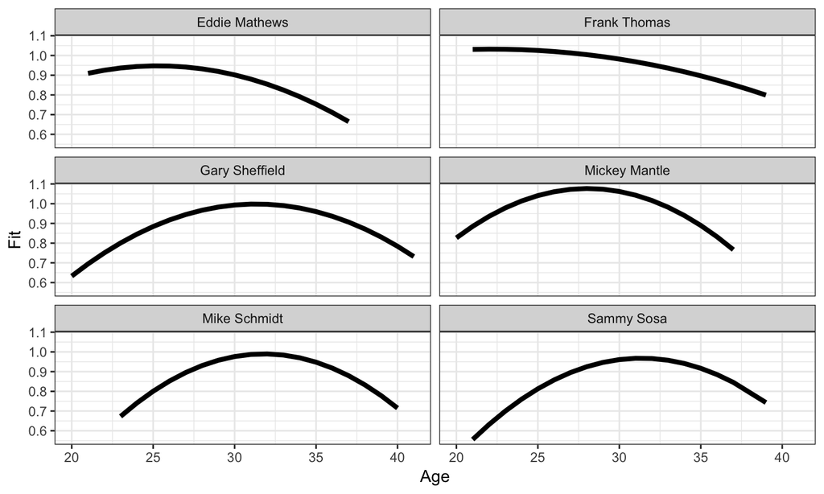

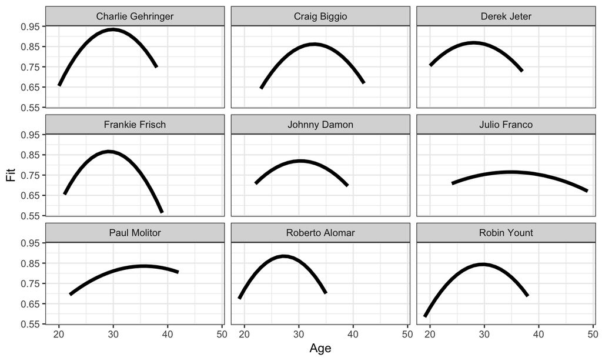